# Vulnérabilité

Maud Quéroué

22 juin 2025

# Calcul de la vulnérabilité

Pour calculer la vulnérabilité des espèces, il faut tenir compte de trois grands facteurs spécifiques à chaque espèce :

- Le score de conservation (CS) qui provient du document : **OFB and GISOM**. *Identification et priorisation de la responsabilité de chaque sous région marine pour les enjeux ornithologiques. (2020)*. Nous avons utilisé les scores de conservation nationaux.
- Le risque collision qui est évalué à partir de quatre critères : le pourcentage de temps en vol à hauteur de pales (**Alt**), la manoeuvrabilité en vol (**Man**), le pourcentage de temps passé en vol (**Ptf**), et un score d’activité nocturne (**Noc**).
- Le risque de déplacement qui est évalué à partir de deux critères : la sensibilité à des perturbations comme des éoliennes, des bateaux, etc. (**Dis**), et la spécialisation à l’habitat (**Spe**). Les données de risque de déplacement et de collision proviennent de l’article de **Bradbury *et al.*** *Mapping Seabird Sensitivity to Offshore Wind Farms (2014)*.

A partir de ces différents facteurs, l’indice de vulnérabilité pour une espèce est calculé de la façon suivante (Bradbury et al, 2014) :

$$Vul = \frac{Alt + Man + Ptf + Noc}{4} \times \frac{Dis + Spe}{2} \times
CS$$

Nous obtenons les scores de vulnérabilité suivant pour les différentes espèces fréquentant le Golfe du Lion :

|  | Species | Alt | Man | Ptf | Noc | Dis | Spe | CS_winter | CS_summer | Vulnérabilité_winter | Vulnérabilité_summer |
| --- | --- | --- | --- | --- | --- | --- | --- | --- | --- | --- | --- |
| 1 | alcids | 0.65 | 3.5 | 1 | 1 | 2.5 | 3 | 4.3 |  | 18.18 |  |
| 2 | fou | 12 | 3 | 3 | 2 | 2 | 1 | 1.8 |  | 13.5 |  |
| 3 | leucophee | 35 | 2 | 2 | 3 | 2 | 1 | 2.8 | 3.5 | 44.1 | 55.12 |
| 4 | tridactyle | 15 | 1 | 3 | 3 | 2 | 2 | 3 |  | 33 |  |
| 5 | labbes | 10 | 1 | 4.67 | 1 | 1 | 2 | 2.3 |  | 14.38 |  |
| 6 | rieuse | 20 | 1 | 1 | 2 | 2 | 2 | 1.3 | 3.3 | 15.6 | 39.6 |
| 7 | melanocephale | 25 | 1 | 2 | 2 | 2 | 2 | 2.8 | 2.3 | 42 | 34.5 |
| 8 | pygmee | 15 | 1 | 3 | 2 | 1 | 3 | 5.5 |  | 57.75 |  |
| 9 | caugek | 10 | 1 | 5 | 1 | 2 | 3 | 2 | 2.5 | 21.25 | 26.56 |
| 10 | baleares | 0 | 3 | 3 | 3 | 1 | 1 | 7 | 6.5 | 15.75 | 14.62 |

[output cut: 10 more lines]

Pour créer une carte de vulnérabilité de l’ensemble des oiseaux marins nicheurs, il faut combiner l’ensemble des cartes de répartion des différentes espèces (estimées via uniquement les compatges, ou pas modèles intégré pour les espèces équipées de GPS) en utilisant l’indice de vulnérabilité comme un facteur de pondération (Bradbury et al, 2014) :

$$SV_{i} = \sum_{sp}Vul_{sp} \times log(N_{i,sp} + 1)$$

Avec $i$ une cellule de la grille, $sp$ les espèces, $Vul$ l’indice de vulnérabilité spécifique à chaque espèce et $N_{i,sp}$ l’effectif estimé par espèce dans la cellule $i$.

Cependant, dans les **modèles Nmixture** utilisés pour estimer des cartes de distributions de chaque espèce, les $N_{i,sp}$ sont des abondances relatives. Nous choisissons donc de standardiser les cartes de répartition pour les différentes espèces de la manière suivante :

$$λ_{i} = \frac{N_{i}}{\sum_{i} N_{i}}$$

Avec $N_{i}$ l’abondance relative estimée dans chaque cellule *i* de la grille pour une espèce donnée. Ainsi, la somme de l’ensemble des cellules standardisées $λ_{i}$ de la grille est 1. Nous considérons donc que l’utilisation de l’habitat est indépendante de l’abondance absolue d’une espèce mais qu’elle varie spatialement à l’intérieur de la zone d’étude.

La vulnérabilité est alors calculée de la manière suivante :

$$SV_{i} = \sum_{sp}Vul_{sp} \times log(λ_{i,sp} + 1)$$
Pour estimer l’incertitude de la variabilité à chaque point de la grille, nous avons utilisé les itérations issues de nos modèles N-mixture. Chaque modèle fournit 1 000 itérations d’estimations des relations entre les observations et les covariables environnementales. À chaque itération, nous générons une carte de distribution pour chacune des espèces, ce qui nous donne 1 000 cartes de distribution par espèce. À partir de ces cartes, nous construisons 1 000 cartes de vulnérabilité, que nous moyennons pour obtenir une carte de vulnérabilité moyenne. Ces cartes nous permettent également de calculer les coefficients de variation, renseignant sur l’incertitude associée à chaque cellule de la grille.

## Vulnérabilité hors reproduction

**Espèces inclues dans le calcul de la vulnérabilité hors reproduction** : Goéland leucophée, Mouette mélanocéphale, Mouette tridactyle, Mouette pygmée, Sterne caugek, Macareux moine, Pingouin torda, Puffin yelkouan ainsi que les Labbes (parasite, pomarin et grand).

Le Fou de Bassan, la Mouettes rieuse et le Puffin des Baléares n’ont pas été retenus car la distribution estimée par les modèles de Nmixture est trop incertaine en lien avec un manque de données.

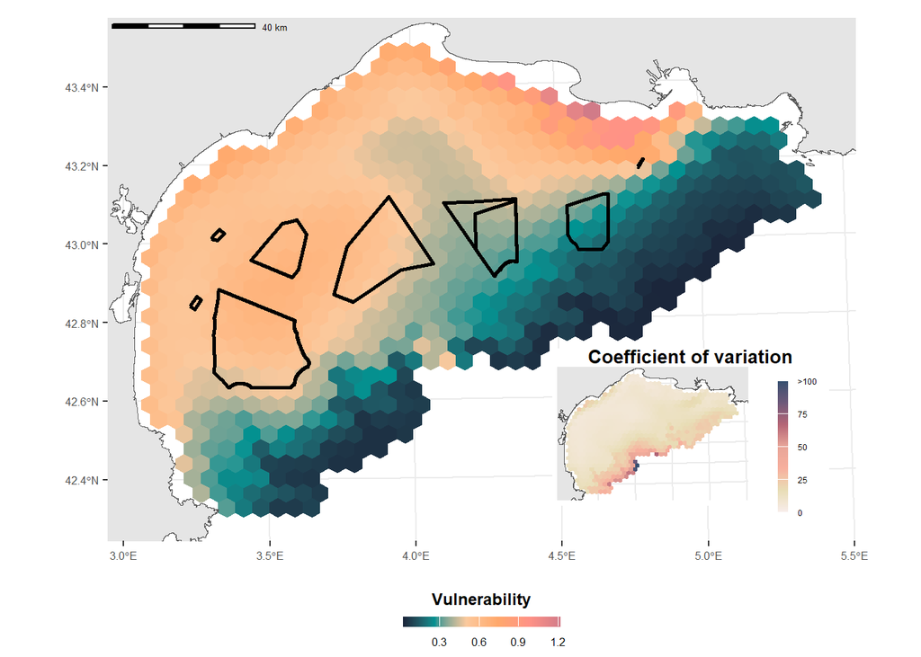

# Reproduction

**Espèces inclues dans le calcul de la vulnérabilité en reproduction** : Goéland leucophée, Mouette mélanocéphale, Sterne caugek, Sterne pierregarin, Puffin yelkouan, Puffin de Scopoli et Océanite tempête.

Les Puffins des Baléares n’ont pas été retenus car la distribution estimée par les modèles de Nmixture est trop incertaine en lien avec un manque de données.

## Vulnérabilité reproduction

### Avec modèle intégré

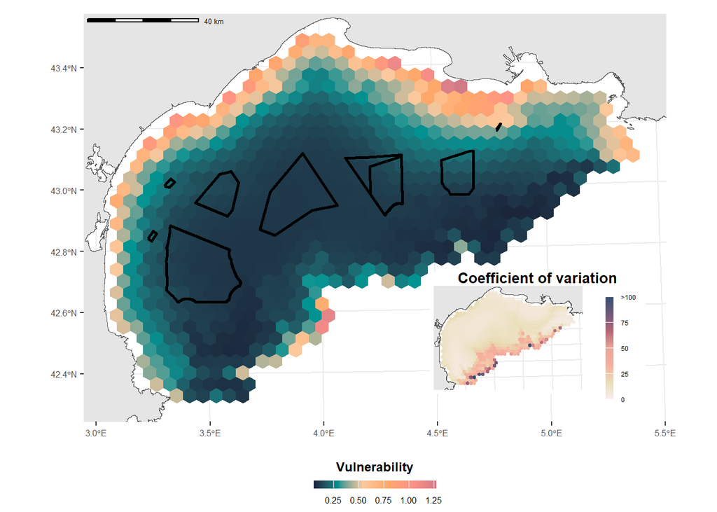